# Reproducible Research: Peer Assessment 1

### Loading and preprocessing the data

#### 1. Load the data

```r
activity <- read.csv("~/GitHub/RepData_PeerAssessment1/activity.csv", stringsAsFactors = FALSE)
```

#### 2. Pre-process the data ignoring the missing values in the dataset.

```r
daysWithSteps <- activity[!is.na(activity["steps"]),]
```

### What is mean total number of steps taken per day?

#### 1. Calculate the total number of steps taken per day

```r
total.stepsPerDay <- tapply(daysWithSteps$steps, daysWithSteps$date, FUN=sum)
```

#### 2. Make a histogram of the total number of steps taken each day

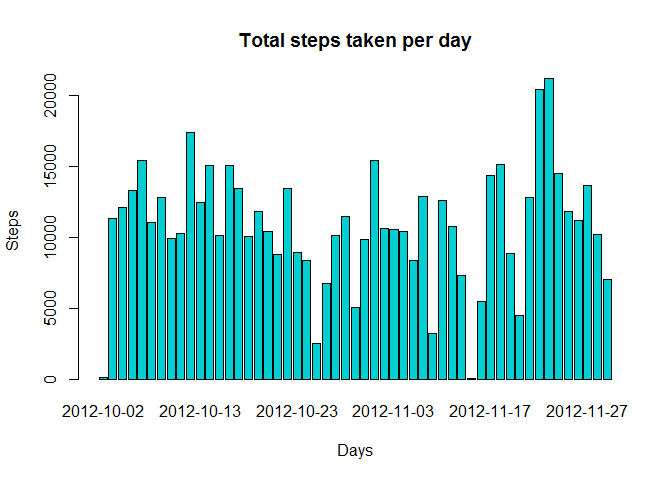

```r
barplot(total.stepsPerDay, main="Total steps taken per day", ylab="Steps", xlab="Days", col="darkturquoise")
```

###### So, the mean is

```r
mean(total.stepsPerDay)
```

```
## [1] 10766.19
```

###### and the median is

```r
median(total.stepsPerDay)
```

```
## [1] 10765
```

### What is the average daily activity pattern?

#### 1. Make a time series plot (i.e. type = “l”) of the 5-minute interval (x-axis) and the average number of steps taken, averaged across all days (y-axis)

##### Firs, calculate the average

```r
averages <- aggregate(x=list(steps=daysWithSteps$steps), by = list(interval=daysWithSteps$interval), FUN=mean)
```

##### Second, draw de plot

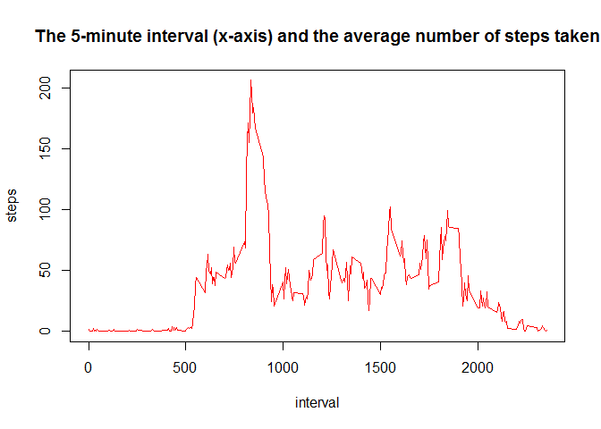

```r
plot(averages, type="l", main="The 5-minute interval (x-axis) and the average number of steps taken", col="red")
```

#### 2. Which 5-minute interval, on average across all the days in the dataset, contains the maximum number of steps?

```r
averages[averages$steps==max(averages$steps),]
```

```
##     interval    steps
## 104      835 206.1698
```

### Imputing missing values

#### 1. Calculate and report the total number of missing values in the dataset (i.e. the total number of rows with NAs)

```r
nrow(activity[is.na(activity$steps) | is.na(activity$interval) | is.na(activity$date),])
```

```
## [1] 2304
```

#### 2. Devise a strategy for filling in all of the missing values in the dataset. The strategy does not need to be sophisticated. For example, you could use the mean/median for that day, or the mean for that 5-minute interval, etc.

```r
new.values <- function(steps, interval){
  newValue <- NA
  if (!is.na(steps))
    newValue <- c(steps)
  else
    newValue <- (averages[averages$interval == interval, "steps"])
  return(newValue)
}
```

#### 3. Create a new dataset that is equal to the original dataset but with the missing data filled in.

```r
newActivity <- activity
newActivity$steps <- mapply(new.values, newActivity$steps, newActivity$interval)
```

#### 4. Make a histogram of the total number of steps taken each day and Calculate and report the mean and median total number of steps taken per day. Do these values differ from the estimates from the first part of the assignment? What is the impact of imputing missing data on the estimates of the total daily number of steps?

##### Calculate the total number of steps taken per day

```r
total.newsStepsPerDay <- tapply(newActivity$steps, newActivity$date, FUN=sum)
```

##### Make a histogram of the total number of steps taken each day

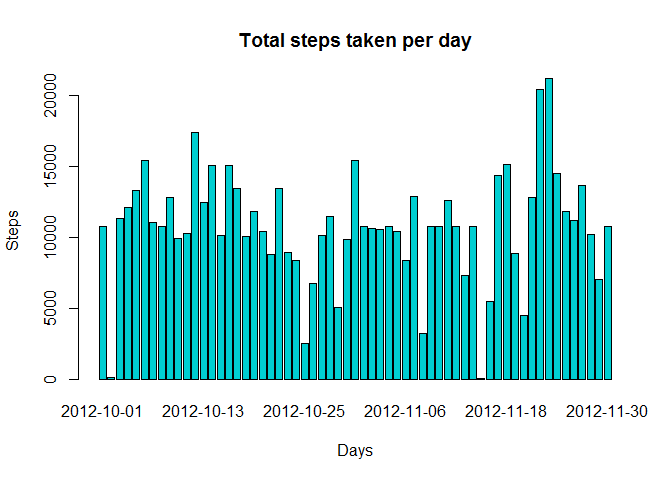

```r
barplot(total.newsStepsPerDay, main="Total steps taken per day", ylab="Steps", xlab="Days", col="darkturquoise")
```

##### the difference between means is

```r
total.stepsPerDayWithNA <- tapply(activity$steps, activity$date, FUN = sum, na.rm = TRUE)
mean(total.stepsPerDayWithNA, na.rm = TRUE)
```

```
## [1] 9354.23
```

```r
mean(total.newsStepsPerDay)
```

```
## [1] 10766.19
```

##### the difference between medians is

```r
median(total.stepsPerDayWithNA, na.rm = TRUE)
```

```
## [1] 10395
```

```r
median(total.newsStepsPerDay)
```

```
## [1] 10766.19
```

##### So, mean and median are higher if we imputing missing data.

### Are there differences in activity patterns between weekdays and weekends?

#### 1. Create a new factor variable in the dataset with two levels - “weekday” and “weekend” indicating whether a given date is a weekday or weekend day.

```r
weekdays.vs.weekends <- function(date){
day <- weekdays(date)
weekdays <- weekdays(Sys.Date()+2:6)
weekends <- weekdays(Sys.Date()+0:1)
if(day %in% weekdays)
return ("weekday")
else if(day %in% weekends)
return("weekend")
else
stop("invalid date")
}

aux.data <- newActivity
aux.data$date <- as.Date(aux.data$date)
aux.data$day <- sapply(aux.data$date, FUN=weekdays.vs.weekends)
```

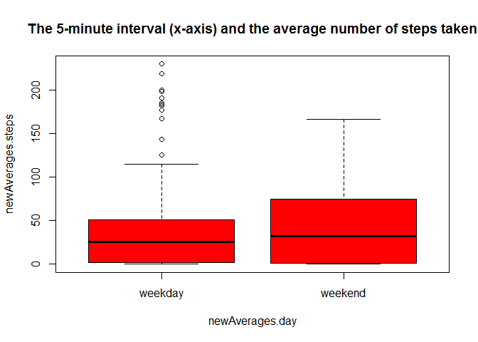

```r
newAverages <- aggregate(steps ~ interval + day, data = aux.data, mean)
frame <- data.frame(newAverages$day,newAverages$steps)
plot(frame, type="l", main="The 5-minute interval (x-axis) and the average number of steps taken", col="red")
```